# Assignment 02: Explore Gapminder and use dplyr

## Exercise 1: Basic **dplyr**

### 1.1

Use **filter()** to subset the **gapminder** data to three countries of your choice in the 1970’s.

```r
gapminder %>%
  filter(country == "Canada" | country == "Chile" | country == "Cambodia",
         year < 1980 & year > 1969) %>%
  kable()
```

| country | continent | year | lifeExp | pop | gdpPercap |
| --- | --- | --- | --- | --- | --- |
| Cambodia | Asia | 1972 | 40.317 | 7450606 | 421.6240 |
| Cambodia | Asia | 1977 | 31.220 | 6978607 | 524.9722 |
| Canada | Americas | 1972 | 72.880 | 22284500 | 18970.5709 |
| Canada | Americas | 1977 | 74.210 | 23796400 | 22090.8831 |
| Chile | Americas | 1972 | 63.441 | 9717524 | 5494.0244 |
| Chile | Americas | 1977 | 67.052 | 10599793 | 4756.7638 |

### 1.2

Use the pipe operator **%>%** to select “country” and “gdpPercap” from your filtered dataset in 1.1.

```r
gapminder %>%
  filter(country == "Canada" | country == "Chile" | country == "Cambodia",
         year < 1980 & year > 1969) %>%
  select(country, gdpPercap)
```

```
## # A tibble: 6 x 2
##   country  gdpPercap
##   <fct>        <dbl>
## 1 Cambodia      422.
## 2 Cambodia      525.
## 3 Canada      18971.
## 4 Canada      22091.
## 5 Chile        5494.
## 6 Chile        4757.
```

### 1.3

Filter gapminder to all entries that have experienced a drop in life expectancy. Be sure to include a new variable that’s the increase in life expectancy in your tibble. Hint: you might find the **lag()** or **diff()** functions useful.

```r
gapminder %>%
  arrange(country, year) %>%
  mutate(lifeIncrease = lifeExp - lag(lifeExp)) %>% # lag(lifeExp) finds the previous values of lifeExp
  filter(lifeIncrease < 0, year != 1952)#exclude the first entry of each country, where the lifeIncrease is the difference between two countries
```

```
## # A tibble: 102 x 7
##    country  continent  year lifeExp     pop gdpPercap lifeIncrease
##    <fct>    <fct>     <int>   <dbl>   <int>     <dbl>        <dbl>
##  1 Albania  Europe     1992    71.6 3326498     2497.       -0.419
##  2 Angola   Africa     1987    39.9 7874230     2430.       -0.036
##  3 Benin    Africa     2002    54.4 7026113     1373.       -0.371
##  4 Botswana Africa     1992    62.7 1342614     7954.       -0.877
##  5 Botswana Africa     1997    52.6 1536536     8647.      -10.2
##  6 Botswana Africa     2002    46.6 1630347    11004.       -5.92
##  7 Bulgaria Europe     1977    70.8 8797022     7612.       -0.09
##  8 Bulgaria Europe     1992    71.2 8658506     6303.       -0.15
##  9 Bulgaria Europe     1997    70.3 8066057     5970.       -0.87
## 10 Burundi  Africa     1992    44.7 5809236      632.       -3.48
## # … with 92 more rows
```

Another solution

```r
gapminder %>%
  arrange(country, year) %>%
  group_by(country) %>%
  mutate(lifeIncrease = lifeExp - lag(lifeExp))
```

```
## # A tibble: 1,704 x 7
## # Groups:   country [142]
##    country     continent  year lifeExp      pop gdpPercap lifeIncrease
##    <fct>       <fct>     <int>   <dbl>    <int>     <dbl>        <dbl>
##  1 Afghanistan Asia       1952    28.8  8425333      779.      NA
##  2 Afghanistan Asia       1957    30.3  9240934      821.       1.53
##  3 Afghanistan Asia       1962    32.0 10267083      853.       1.66
##  4 Afghanistan Asia       1967    34.0 11537966      836.       2.02
##  5 Afghanistan Asia       1972    36.1 13079460      740.       2.07
##  6 Afghanistan Asia       1977    38.4 14880372      786.       2.35
##  7 Afghanistan Asia       1982    39.9 12881816      978.       1.42
##  8 Afghanistan Asia       1987    40.8 13867957      852.       0.968
##  9 Afghanistan Asia       1992    41.7 16317921      649.       0.852
## 10 Afghanistan Asia       1997    41.8 22227415      635.       0.0890
## # … with 1,694 more rows
```

### 1.4

Filter gapminder so that it shows the max GDP per capita experienced by each country. Hint: you might find the **max()** function useful here.

```r
gapminder %>%
  group_by(country) %>%
  mutate(maxgpdPercap = max(gdpPercap)) %>%
  filter(gdpPercap == maxgpdPercap)
```

```
## # A tibble: 142 x 7
## # Groups:   country [142]
##    country     continent  year lifeExp       pop gdpPercap maxgpdPercap
##    <fct>       <fct>     <int>   <dbl>     <int>     <dbl>        <dbl>
##  1 Afghanistan Asia       1982    39.9  12881816      978.         978.
##  2 Albania     Europe     2007    76.4   3600523     5937.        5937.
##  3 Algeria     Africa     2007    72.3  33333216     6223.        6223.
##  4 Angola      Africa     1967    36.0   5247469     5523.        5523.
##  5 Argentina   Americas   2007    75.3  40301927    12779.       12779.
##  6 Australia   Oceania    2007    81.2  20434176    34435.       34435.
##  7 Austria     Europe     2007    79.8   8199783    36126.       36126.
##  8 Bahrain     Asia       2007    75.6    708573    29796.       29796.
##  9 Bangladesh  Asia       2007    64.1 150448339     1391.        1391.
## 10 Belgium     Europe     2007    79.4  10392226    33693.       33693.
## # … with 132 more rows
```

### 1.5

Produce a scatterplot of Canada’s life expectancy vs. GDP per capita using ggplot2, without defining a new variable. That is, after filtering the gapminder data set, pipe it directly into the **ggplot()** function. Ensure GDP per capita is on a log scale.

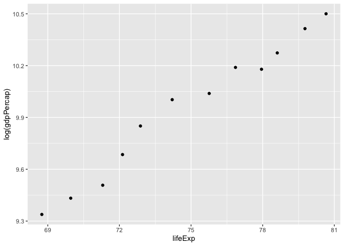

```r
gapminder %>%
  filter(country == "Canada") %>%
  ggplot(aes(lifeExp, log(gdpPercap))) +
  geom_point()
```

## Exercise 2: Explore individual variables with **dplyr**

Pick one categorical variable and one quantitative variable to explore. Answer the following questions in whichever way you think is appropriate, using dplyr:

- What are possible values (or range, whichever is appropriate) of each variable?
- What values are typical? What’s the spread? What’s the distribution? Etc., tailored to the variable at hand.

I picked one categorical variable **country** and one quantatative variable **pop**.

### country

The possible values of **country**:

```r
gapminder %>%
  distinct(country)
```

```
## # A tibble: 142 x 1
##    country
##    <fct>
##  1 Afghanistan
##  2 Albania
##  3 Algeria
##  4 Angola
##  5 Argentina
##  6 Australia
##  7 Austria
##  8 Bahrain
##  9 Bangladesh
## 10 Belgium
## # … with 132 more rows
```

The count of each possible value of **country**

```r
gapminder %>%
  group_by(country) %>%
  count()
```

```
## # A tibble: 142 x 2
## # Groups:   country [142]
##    country         n
##    <fct>       <int>
##  1 Afghanistan    12
##  2 Albania        12
##  3 Algeria        12
##  4 Angola         12
##  5 Argentina      12
##  6 Australia      12
##  7 Austria        12
##  8 Bahrain        12
##  9 Bangladesh     12
## 10 Belgium        12
## # … with 132 more rows
```

### pop

The range of **pop**:

```r
range(gapminder$pop)
```

```
## [1]      60011 1318683096
```

The spread of **pop**:

```r
summary(gapminder$pop)
```

```
##      Min.   1st Qu.    Median      Mean   3rd Qu.      Max.
## 6.001e+04 2.794e+06 7.024e+06 2.960e+07 1.959e+07 1.319e+09
```

The distribution of **pop**:

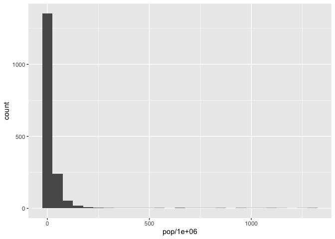

```r
ggplot(gapminder, aes(pop/1000000))+
  geom_histogram(binwidth = 50)
```

The distribution of **pop** is very right skewed. Most values are below 150 million, while a few outliers are larger than 1 billion.

## Exercise 3: Explore various plot types

- A scatterplot of two quantitative variables.
- One other plot besides a scatterplot.

### Scatterplot

For this exercise, I used **mtcars**. I made a scatterplot of **mpg**(Miles/(US) gallon) and **wt**(Weight (1000 lbs)). The plot shows a negative relationship between the fuel economy and the weight.

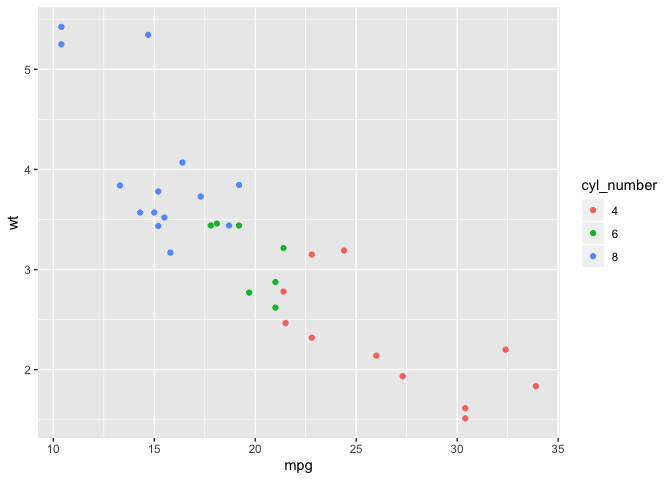

```r
cyl_number <- as.character(mtcars$cyl) #Change the type of cyl into character because there are only three discrete values.
ggplot(mtcars, aes(mpg, wt))+
  geom_point(aes(color= cyl_number))
```

### Boxplot

I made a boxplot showing the distribution of fuel economy(mpg) of cars with different number of cylinders.

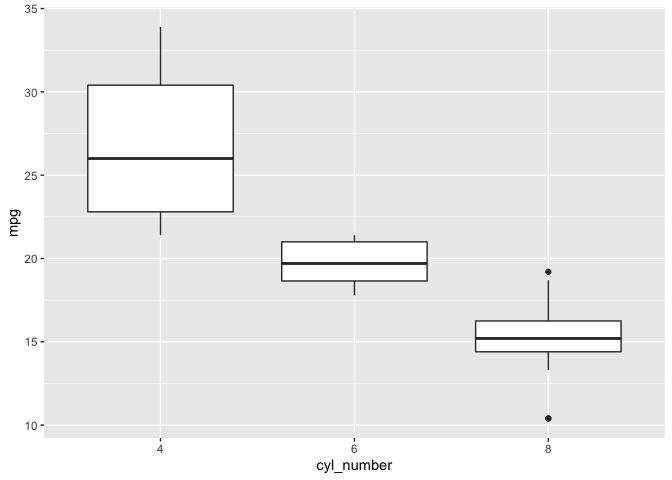

```r
ggplot(mtcars, aes(cyl_number,mpg))+
  geom_boxplot()
```